# Reproducible Research: Project 1

lnma

4/27/2020

## Load and preprocess data

1. Unzip data to csv file

```r
url <- "https://d396qusza40orc.cloudfront.net/repdata%2Fdata%2Factivity.zip"
destfile <- "step_data.zip"
download.file(url, destfile)
unzip(destfile)
```

2. Load the data

```r
activity <- read.csv("activity.csv", sep = ",")
```

3. Add a column of day that the first day is 2012-10-01

```r
activity$date<-as.Date(as.character(activity$date))
activity$day<-activity$date-activity$date[1]+1
```

4. Have a look at the data

```r
str(activity)
```

```
## 'data.frame':    17568 obs. of  4 variables:
##  $ steps   : int  NA NA NA NA NA NA NA NA NA NA ...
##  $ date    : Date, format: "2012-10-01" "2012-10-01" ...
##  $ interval: int  0 5 10 15 20 25 30 35 40 45 ...
##  $ day     : 'difftime' num  1 1 1 1 ...
##   ..- attr(*, "units")= chr "days"
```

```r
head(activity)
```

```
##   steps       date interval    day
## 1    NA 2012-10-01        0 1 days
## 2    NA 2012-10-01        5 1 days
## 3    NA 2012-10-01       10 1 days
## 4    NA 2012-10-01       15 1 days
## 5    NA 2012-10-01       20 1 days
## 6    NA 2012-10-01       25 1 days
```

## What is mean total number of steps taken per day?

1. Calculate the total number of steps taken per day

```r
totalStep_day<-tapply(activity$steps,activity$day,sum,na.rm=TRUE)
```

2. Barplot total number of steps taken for each day  
   The mean and median values are plotted as red and blue lines respectively

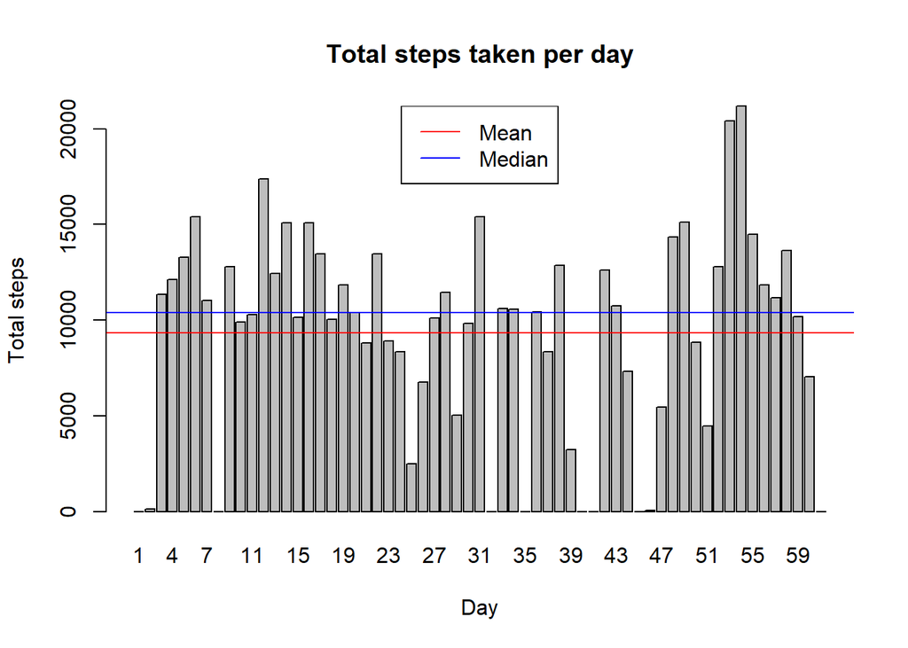

```r
barplot(totalStep_day,main='Total steps taken per day',
     xlab = 'Day',ylab='Total steps')
abline(h = mean(totalStep_day), lty = 1, lwd = 1, col = "red")
abline(h = median(totalStep_day), lty = 1, lwd = 1, col = "blue")
legend('top',c('Mean','Median'),col=c('red','blue'),lty = c(1,1),lwd=c(1,1))
```

3. Histogram of total number of steps taken for each day  
   The mean and median values are plotted as red and blue lines respectively

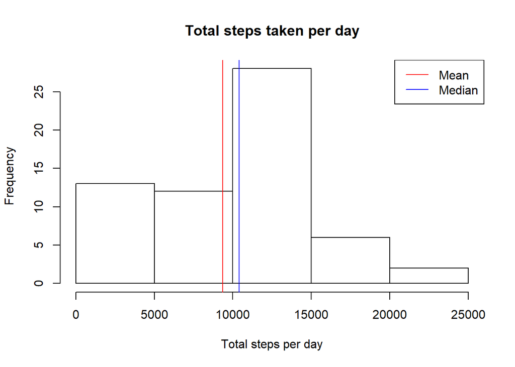

```r
hist(totalStep_day,main='Total steps taken per day',
        xlab = 'Total steps per day',ylab='Frequency')
#add lines of mean and median in red and blue respectively
abline(v = mean(totalStep_day), lty = 1, lwd = 1, col = "red")
abline(v = median(totalStep_day), lty = 1, lwd = 1, col = "blue")
legend('topright',c('Mean','Median'),col=c('red','blue'),lty = c(1,1),lwd=c(1,1))
```

## What is the average daily activity pattern?

1. Calculate the average number of steps taken per interval

```r
avgStep_interval<-tapply(activity$steps,activity$interval,mean,na.rm=TRUE)
```

2. Make a time series plot of the 5-minute interval (x-axis) and the average number of steps taken, averaged across all days (y-axis), the maxium point is highlighted

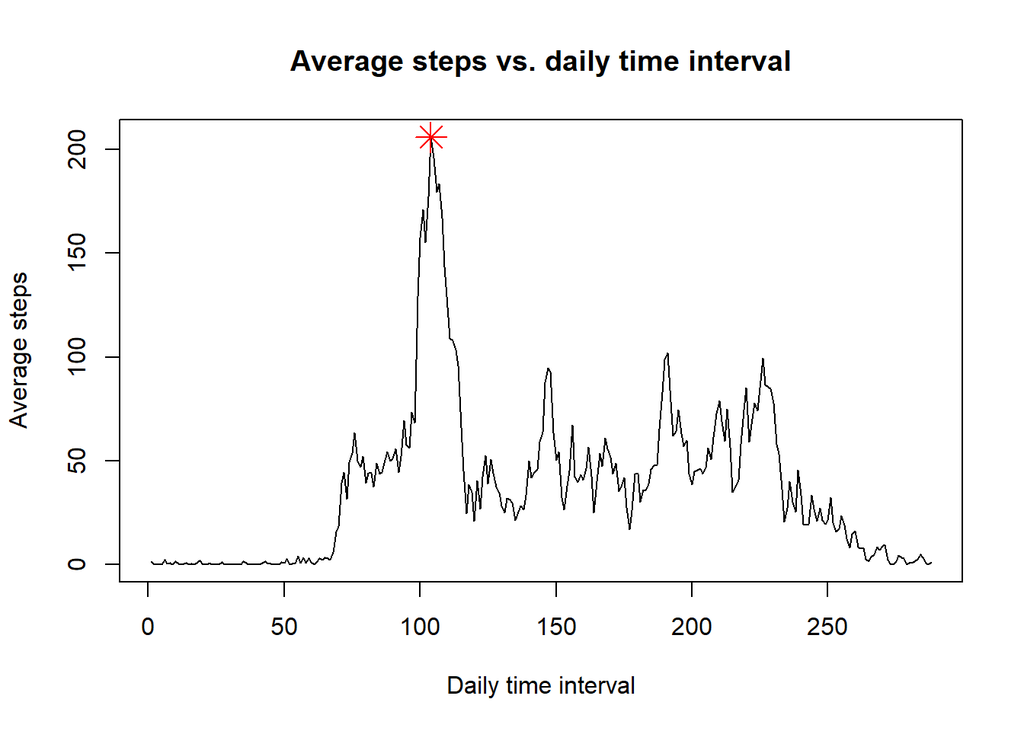

```r
plot(avgStep_interval,ty='l',main='Average steps vs. daily time interval',
     xlab = 'Daily time interval',ylab = 'Average steps')
#maximum average number of steps
x_max=as.numeric(which(avgStep_interval==max(avgStep_interval)))
y_max=max(avgStep_interval)
p<-c(round(x_max),round(y_max))
points(t(p),pch=8,col='red',cex=2)
```

3.Which 5-minute interval, on average across all the days in the dataset, contains the maximum number of steps?  
Interval (835) contains on average the maximum number of steps (206.1698).

```r
x_max=which(avgStep_interval==max(avgStep_interval))
y_max=max(avgStep_interval)
x_max
```

```
## 835
## 104
```

```r
y_max
```

```
## [1] 206.1698
```

## Imputing missing values

1.Calculate and report the total number of missing values in the dataset

```r
na_number_steps<-sum(is.na(activity$steps))
na_number_steps
```

```
## [1] 2304
```

2. Devise a strategy for filling in all of the missing values in the dataset. The strategy uses the mean mean for that 5-minute interval.

```r
activity_day<-split(activity,activity$day)
avgStep_day<-as.numeric(tapply(activity$steps,activity$day,mean,na.rm=TRUE))
activity_NA<-data.frame()
for(i in 1:length(avgStep_day)){
        if (sum(!is.na(activity_day[[i]][,1]))==0){
                activity_day[[i]]$steps<-avgStep_interval
        }else if(sum(is.na(activity_day[[i]]$steps))!=0){
                for (j in 1:length(activity_day[[i]]$steps)){
                        activity_day[[i]][j,1]<-avgStep_interval[j]
                }
        }
        activity_NA<-rbind(activity_NA,activity_day[[i]])
}
```

3. Create a new dataset that is equal to the original dataset but with the missing data filled in.

```r
head(activity_NA)
```

```
##       steps       date interval    day
## 1 1.7169811 2012-10-01        0 1 days
## 2 0.3396226 2012-10-01        5 1 days
## 3 0.1320755 2012-10-01       10 1 days
## 4 0.1509434 2012-10-01       15 1 days
## 5 0.0754717 2012-10-01       20 1 days
## 6 2.0943396 2012-10-01       25 1 days
```

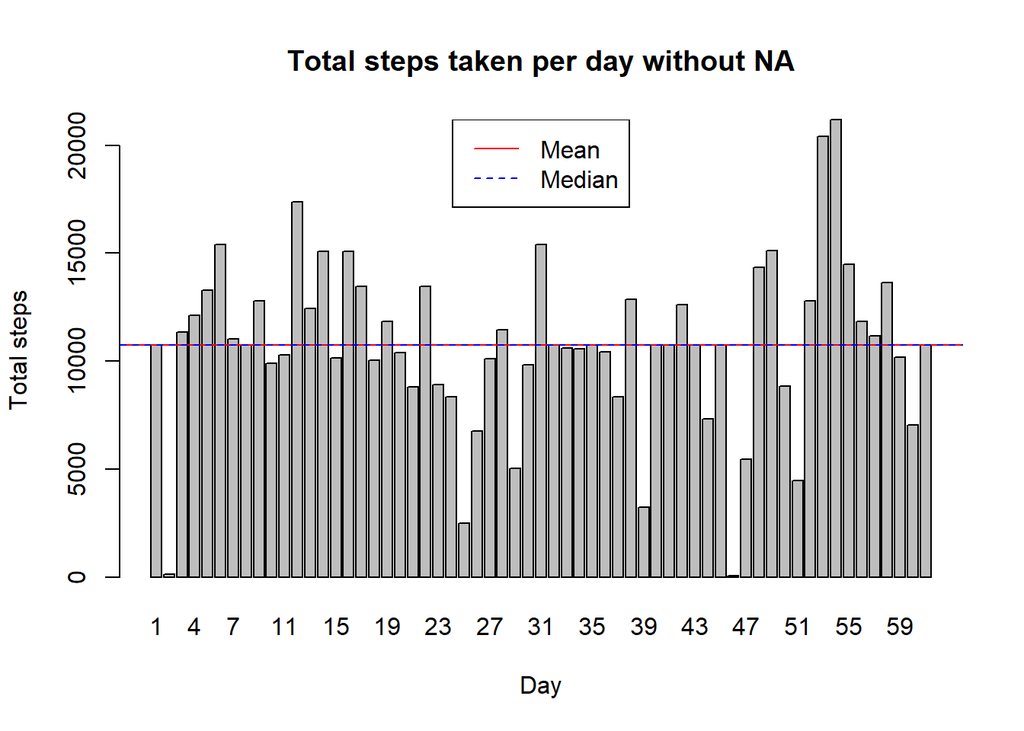

```r
totalStep_NA<-tapply(activity_NA$steps,activity_NA$day,sum,na.rm=TRUE)
barplot(totalStep_NA,main='Total steps taken per day without NA',
        xlab = 'Day',ylab='Total steps')
abline(h = mean(totalStep_NA), lty = 1, lwd = 1, col = "red")
abline(h = median(totalStep_NA), lty = 2, lwd = 1, col = "blue")
legend('top',c('Mean','Median'),col=c('red','blue'),lty = c(1,2),lwd=c(1,1))
```

Histogram of total number of steps taken for each day without NAs

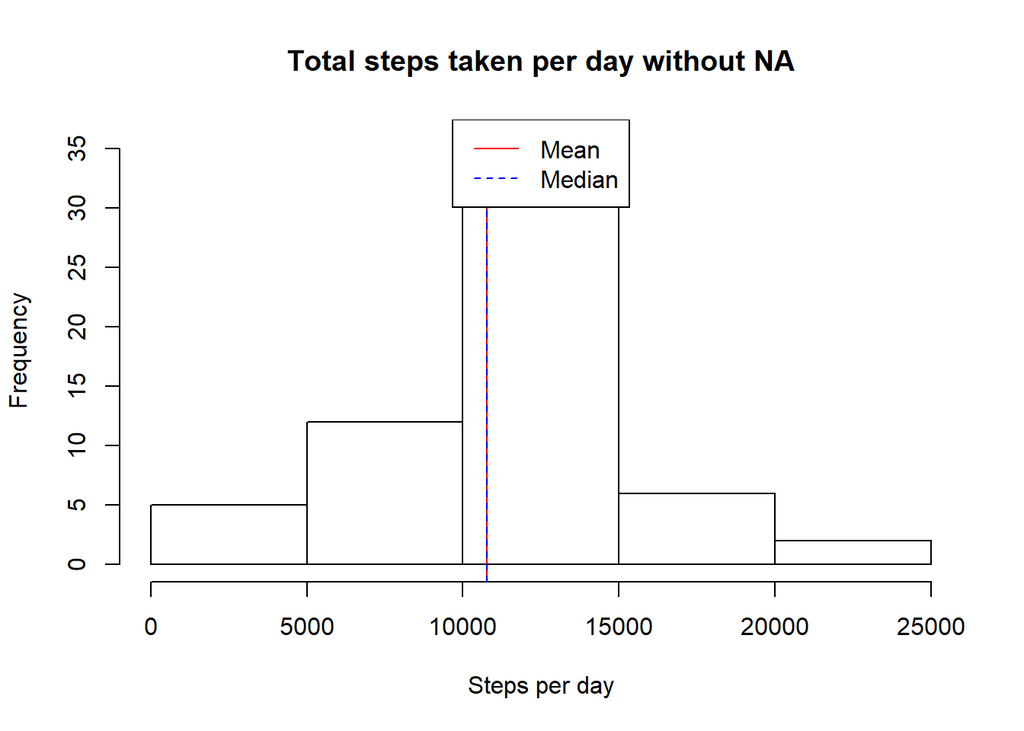

```r
hist(totalStep_NA,main='Total steps taken per day without NA',
        xlab = 'Steps per day',ylab='Frequency')
abline(v = mean(totalStep_NA), lty = 1, lwd = 1, col = "red")
abline(v = median(totalStep_NA), lty = 2, lwd = 1, col = "blue")
legend('top',c('Mean','Median'),col=c('red','blue'),lty = c(1,2),lwd=c(1,1))
```

## Are there differences in activity patterns between weekdays and weekends?

1. Create a new factor variable in the dataset with two levels – “weekday” and “weekend” indicating whether a given date is a weekday or weekend day.

```r
activity$week<-weekdays(activity$date)
activity$week<-factor(activity$week,
                      levels = c('Monday','Tuesday','Wednesday','Thursday','Friday','Saturday','Sunday'),
                      ordered = TRUE)
activity$weekday[activity$week%in%c('Monday','Tuesday','Wednesday','Thursday','Friday')]<-'weekday'
activity$weekday[activity$week%in%c('Saturday','Sunday')]<-'weekend'

#average number of steps for weekdays and weekends
activity$weekday<-factor(activity$weekday,levels = c('weekday','weekend'))
avgStep_wd<-tapply(activity[activity$weekday=='weekday','steps'],
                         activity[activity$weekday=='weekday','interval'],mean,na.rm=TRUE)
avgStep_we<-tapply(activity[activity$weekday=='weekend','steps'],
                   activity[activity$weekday=='weekend','interval'],mean,na.rm=TRUE)
```

2. Make a panel plot containing a time series plot of the 5-minute interval (x-axis) and the average number of steps taken, averaged across all weekday days or weekend days (y-axis).

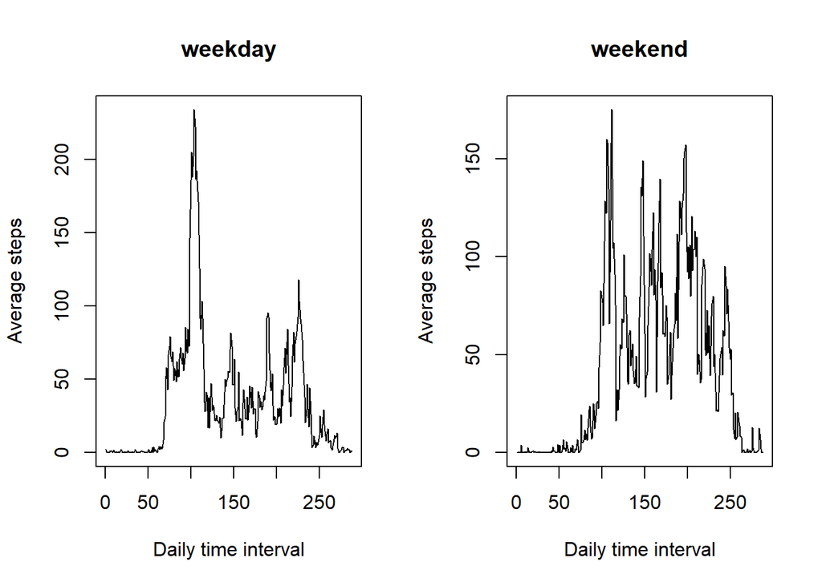

```r
par(mfrow=c(1,2))
plot(avgStep_wd,ty='l',main='weekday',xlab = 'Daily time interval',ylab = 'Average steps')
plot(avgStep_we,ty='l',main='weekend',xlab = 'Daily time interval',ylab = 'Average steps')
```

```r
par(mfrow=c(1,1))
```